# PSTAT131 Homework 6

Shivani Kharva

2022-11-16

### Initial Setup

```r
# Loading the data/ packages
pokemon_data <- read.csv("data/Pokemon.csv")
library(tidymodels)
library(ISLR)
library(tidyverse)
library(discrim)
library(poissonreg)
library(glmnet)
```

```r
library(corrr)
library(corrplot)
library(randomForest)
library(xgboost)
library(rpart.plot)
library(vip)
library(ranger)
tidymodels_prefer()
set.seed(0124)
```

### Exercise 1

```r
# Loading in the `janitor` package
library(janitor)
# Using clean_names() on the pokemon data
pokemon_clean <- clean_names(pokemon_data)
```

```r
# Filtering the data set to only contain Pokemon of the given types
pokemon_final <- pokemon_clean %>%
  filter(type_1 %in% c("Bug", "Fire", "Grass", "Normal", "Water", "Psychic"))
```

```r
# Converting given variables to factors
pokemon_final$type_1 <- as.factor(pokemon_final$type_1)
pokemon_final$legendary <- as.factor(pokemon_final$legendary)
pokemon_final$generation <- as.factor(pokemon_final$generation)
```

```r
# Splitting the data and stratifying by `type_1`
pokemon_split <- initial_split(pokemon_final, prop = 0.7, strata = type_1)
pokemon_train <- training(pokemon_split)
pokemon_test <- testing(pokemon_split)
```

```r
# Using v-fold cross validation with 5 folds and type_1 strata
pokemon_folds <- vfold_cv(pokemon_train, v = 5, strata = type_1)
```

```r
# Setting up the recipe
pokemon_recipe <- recipe(type_1 ~ legendary + generation + sp_atk + attack + speed + defense + hp + sp_def, data = pokemon_train) %>%
  # Dummy coding `legendary` and `generation`
  step_dummy(legendary, generation) %>%
  # Centering and scaling all predictors
  step_normalize(all_predictors())
```

### Exercise 2

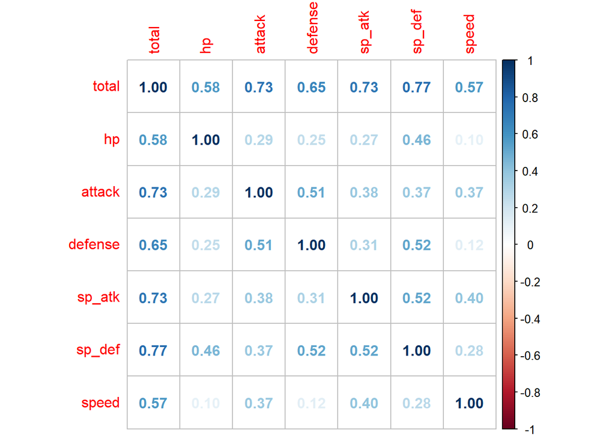

```r
# Creating correlation matrix of training set (with continuous variables)
cor_pokemon_train <- pokemon_train %>%
  # Taking out all discrete/categorical variables
  select(-c('type_1', 'legendary', 'generation', 'x', 'name', 'type_2')) %>%
  cor() %>%
  corrplot(method = 'number')
```

```r
cor_pokemon_train
```

```
## $corr
##             total        hp    attack   defense    sp_atk    sp_def     speed
## total   1.0000000 0.5798141 0.7327417 0.6547512 0.7265970 0.7687095 0.5704065
## hp      0.5798141 1.0000000 0.2863998 0.2478412 0.2703046 0.4586364 0.1004461
## attack  0.7327417 0.2863998 1.0000000 0.5108498 0.3765649 0.3702973 0.3729559
## defense 0.6547512 0.2478412 0.5108498 1.0000000 0.3113891 0.5228337 0.1213747
## sp_atk  0.7265970 0.2703046 0.3765649 0.3113891 1.0000000 0.5224277 0.3952723
## sp_def  0.7687095 0.4586364 0.3702973 0.5228337 0.5224277 1.0000000 0.2751434
## speed   0.5704065 0.1004461 0.3729559 0.1213747 0.3952723 0.2751434 1.0000000
##
## $corrPos
##      xName   yName x y      corr
## 1    total   total 1 7 1.0000000
## 2    total      hp 1 6 0.5798141
## 3    total  attack 1 5 0.7327417
```

[output cut: 50 more lines]

I notice that each of the battle statistics is positively correlated with `total` (all are > 0.5). This makes sense because, as each battle statistic increases, the total would increase as well because the total is the total of the battle statistics (the total is actually the sum of all six battle statistics).

Overall, there are no particularly strong relationships and there are also no negative correlations.

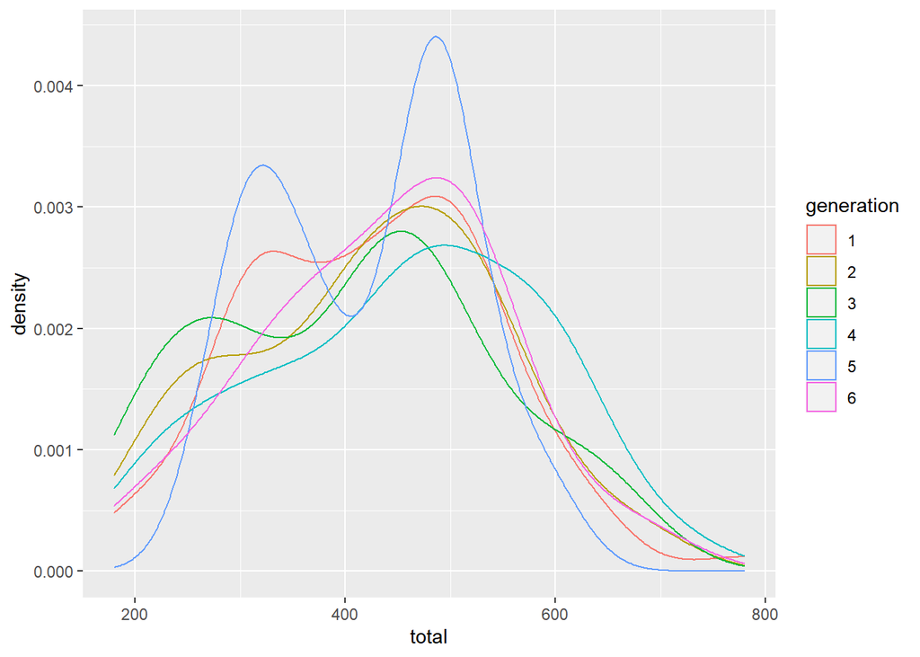

```r
# Creating density plots for relationship between `generation` and `total`
ggplot(pokemon_train, aes(x = total, color = generation)) +
  geom_density()
```

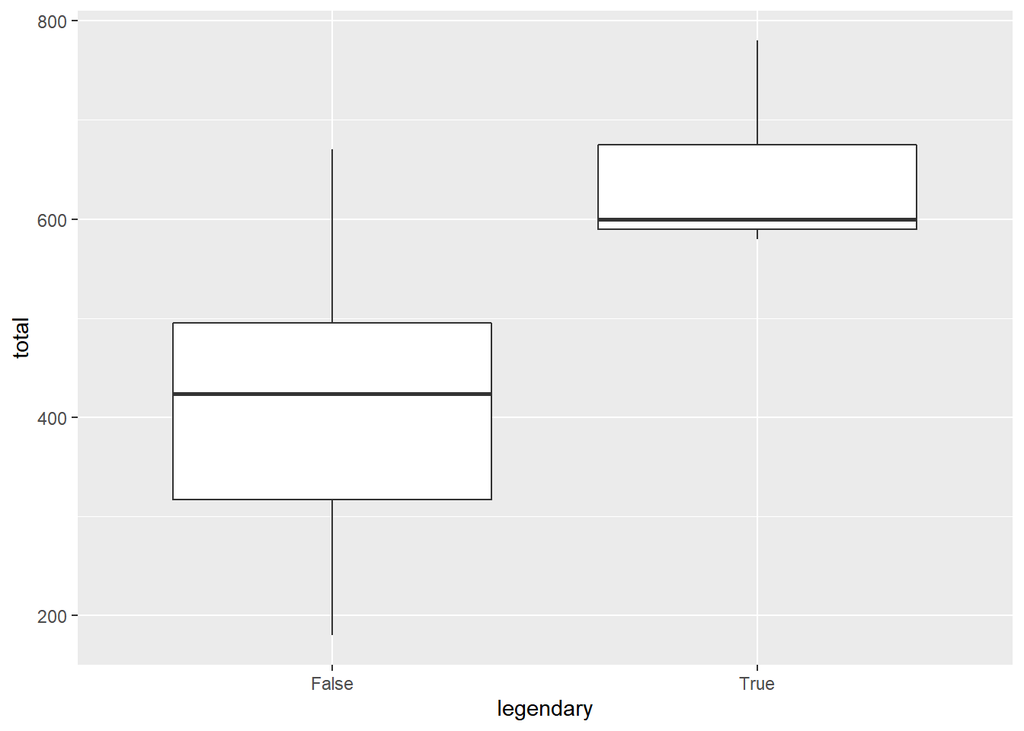

```r
# Creating boxplots for relationship between `legendary` and `total`
ggplot(pokemon_train, aes(x = legendary, y = total)) +
  geom_boxplot()
```

From the boxplots, it appears that if a Pokemon is legendary, it generally has higher total battle statistics than Pokemon that are not legendary. This makes sense because being legendary is rarer among Pokemon.

### Exercise 3

```r
# setting up decision tree model
tree_spec <- decision_tree() %>%
  set_engine("rpart") %>%
  set_mode("classification")

# Setting up decision tree workflow
tree_workflow <- workflow() %>%
  add_recipe(pokemon_recipe) %>%
  add_model(tree_spec %>%
              # specifying that we want to tune cost complexity
              set_args(cost_complexity = tune()))
```

```r
# Creating grid with same levels and range as lab 7
cost_comp_grid <- grid_regular(cost_complexity(range = c(-3, -1)), levels = 10)

# Tuning cost complexity and specifying metric roc_auc
tune_res <- tune_grid(
  tree_workflow,
  resamples = pokemon_folds,
  grid = cost_comp_grid,
  metrics = metric_set(roc_auc)
)

# Saving the fit
write_rds(tune_res, file = "decision_tree.rds")
```

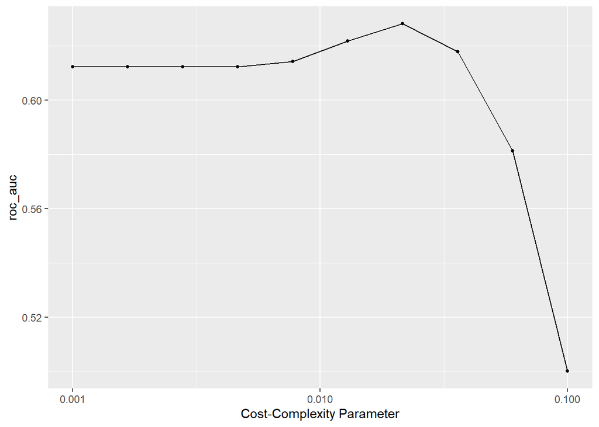

```r
# Loading in the fit
decision_tree_tune_res <- read_rds("decision_tree.rds")

# Printing an autoplot of the results
autoplot(decision_tree_tune_res)
```

I notice that, at first, as the cost complexity parameter increases, the decision tree performs slightly better. However, as the cost complexity parameter becomes too high, the roc_auc drops a great amount. Based on the plot, a single decision tree performs better with smaller (near 0.001) to mid (near 0.010) values of the complexity penalty (best at mid values slightly greater than 0.010). This makes sense because, as the cost complexity parameter increases, the penalty increases, which decreases the size of the tree (because it imposes a harsher penalty on bigger trees). Higher values of the cost complexity parameter result in lower ROC AUC values because, if the tree is penalized too much, it cannot end up with enough leaf nodes to make accurate predictions (can get too small). When the penalty is nonexistant, the tree overfits, but if the penalty gets big enough, we cripple the tree by not letting it grow enough leaves. So, the single decision tree here does better with lower and mid values of complexity penalty.

### Exercise 4

```r
decision_tree_best_roc_auc <- decision_tree_tune_res %>%
  collect_metrics() %>%
  arrange(desc(mean)) %>%
  head(1)

decision_tree_best_roc_auc
```

```
## # A tibble: 1 × 7
##   cost_complexity .metric .estimator  mean     n std_err .config
##             <dbl> <chr>   <chr>      <dbl> <int>   <dbl> <chr>
## 1          0.0215 roc_auc hand_till  0.628     5  0.0153 Preprocessor1_Model07
```

The `roc_auc` of the best-performing pruned decision tree on the folds is about 0.6282059.

### Exercise 5

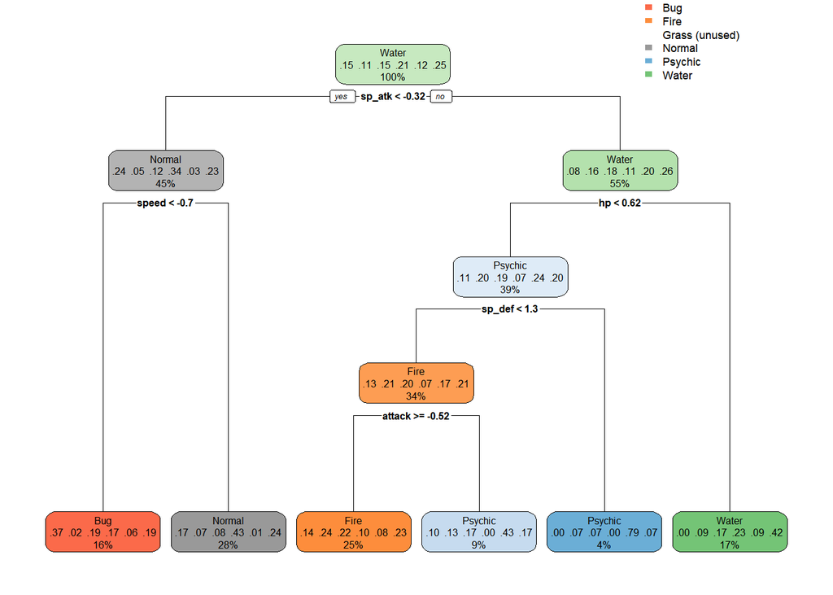

```r
# Fitting best-performing pruned decision tree with training set
best_complexity_decision_tree <- select_best(decision_tree_tune_res)
decision_tree_final <- finalize_workflow(tree_workflow, best_complexity_decision_tree)
decision_tree_final_fit <- fit(decision_tree_final, data = pokemon_train)

# Using rpart.plot to visualize the model
decision_tree_final_fit %>%
  extract_fit_engine() %>%
  rpart.plot()
```

### Exercise 5

```r
# Setting up random forest model with specified tuning parameters and engine
rf_spec <- rand_forest(mtry = tune(), trees = tune(), min_n = tune()) %>%
  set_engine("ranger", importance = "impurity") %>%
  set_mode("classification")
```

The `mtry` hyperparameter specifies how many predictors will be randomly sampled from all the predictors at each split when the random forest model is created. The `trees` hyperparameter specifies how many trees will be in the ensemble. The `min_n` hyperparameter specifies the minimum number of data points that a node must have before splitting that node further (if the number of data points is less than the `min_n` value, the node will not be split further).

```r
# Setting up random forest workflow
rf_workflow <- workflow() %>%
  add_recipe(pokemon_recipe) %>%
  add_model(rf_spec)

# Creating a regular grid with 8 levels each
rf_parameter_grid <- grid_regular(mtry(range = c(1, 8)), trees(range = c(200,1000)), min_n(range = c(1,10)), levels = 8)
```

Since `mtry` represents the number of predictors randomly chosen from all predictors at each split, if `mtry` was less than 1, we would have 0 predictors, and if `mtry` was greater than 8, the model would not work because we only have 8 predictors total. If `mtry` = 8, our model would be a Bagging model (where we let it choose from the same predictors at each split; the trees would be very correlated and not independent).

### Exercise 6

```r
# Tuning the model with roc_auc as a metric
rf_tune_res <- tune_grid(
  rf_workflow,
  resamples = pokemon_folds,
  grid = rf_parameter_grid,
  metrics = metric_set(roc_auc)
)

# Saving the fit
write_rds(rf_tune_res, file = "rf.rds")
```

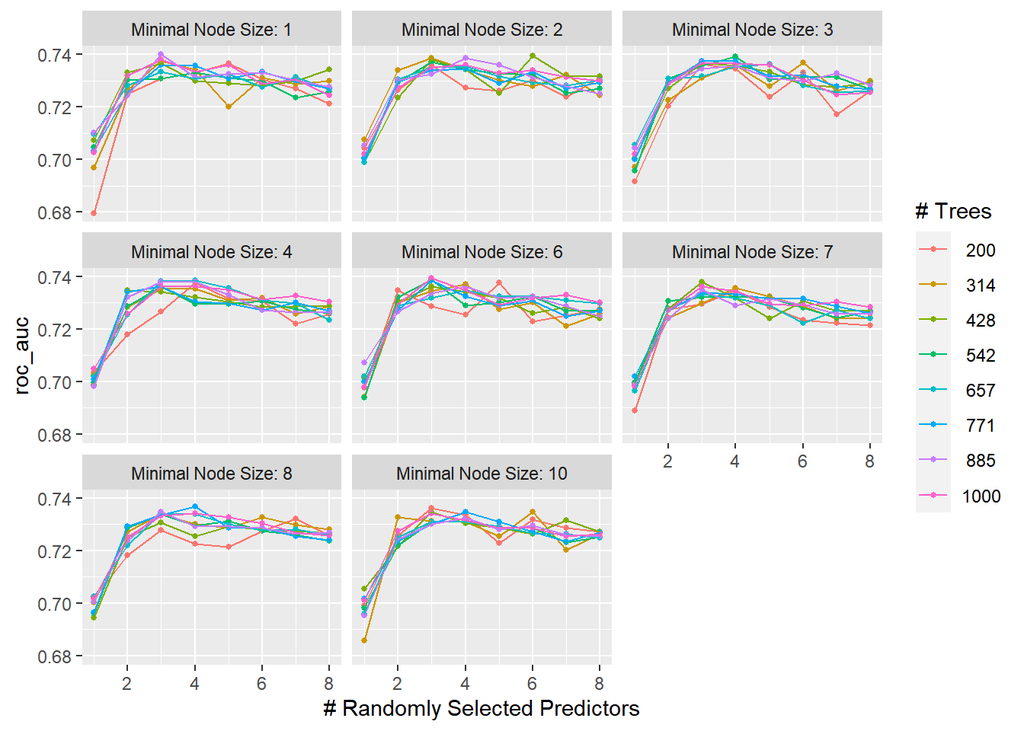

```r
# Loading in the random forest
rf_tuned <- read_rds(file = "rf.rds")

# Producing autoplot of results
autoplot(rf_tuned)
```

In each of the plots, it appears that low values of `mtry` (predictors randomly selected) have lower values of `roc_auc`. The `roc_auc` also appears to generally decrease at `mtry` gets too high. `mtry` values around 2-5 seem to generally yield the best results among the plots. The `mtry` value definitely appears to have the biggest impact on model performance.

As for `min_n`, the patterns in the plots appear to be quite similar for every chosen value of minimal node size; however, the curved parts of the graphs appear to be (very slightly) higher for lower `min_n` values.

Also, the value of `trees` does not appear to have much of an effect on model performance as the colored lines overlap quite a bit. The best performing value of `trees` appears to be 885.

### Exercise 7

```r
# Finding roc_auc of best performing random forest model on folds
rf_best_roc_auc <- rf_tuned %>%
  collect_metrics() %>%
  arrange(desc(mean)) %>%
  head(1)

rf_best_roc_auc
```

```
## # A tibble: 1 × 9
##    mtry trees min_n .metric .estimator  mean     n std_err .config
##   <int> <int> <int> <chr>   <chr>      <dbl> <int>   <dbl> <chr>
## 1     3   885     1 roc_auc hand_till  0.740     5  0.0133 Preprocessor1_Model0…
```

The `roc_auc` of the best-performing random forest model on the folds is 0.7401061.

### Exercise 8

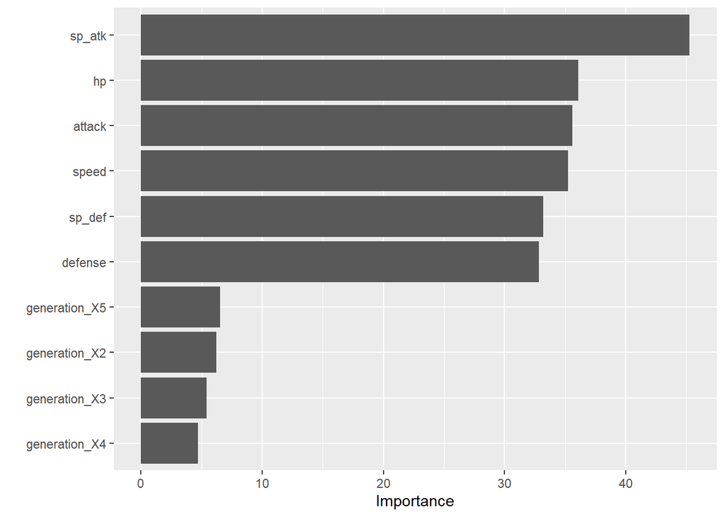

```r
best_rf <- select_best(rf_tuned)
rf_final_workflow <- finalize_workflow(rf_workflow, best_rf)
rf_final_fit <- fit(rf_final_workflow, data = pokemon_train)

rf_final_fit %>%
  extract_fit_engine() %>%
  vip()
```

The variables that were the most useful were `sp_atk`, `hp`, `speed`, `attack`, `sp_def`, and `defense` (especially `sp.atk`). The variables that were the least useful were `generation_X5`, `generation_X2`, `generation_X3`, and `generation_X4`. I expected the six battle statistics to be the most useful, however, I did not expect the generations to be the least useful. Although, that does make sense that generation would not really matter if each generation contains all the same types.

### Exercise 9

```r
# Setting up boosted tree model
boosted_spec <- boost_tree(trees = tune()) %>%
  set_engine("xgboost") %>%
  set_mode("classification")

# Setting up boosted trees workflow
boosted_workflow <- workflow() %>%
  add_recipe(pokemon_recipe) %>%
  add_model(boosted_spec)

# Creating regular grid
boosted_grid <- grid_regular(trees(range = c(10, 2000)), levels = 10)
```

```r
# Tuning and specifying roc_auc
boosted_tune_res <- tune_grid(
  boosted_workflow,
  resamples = pokemon_folds,
  grid = boosted_grid,
  metrics = metric_set(roc_auc)
)

# Saving the fit
write_rds(boosted_tune_res, file = "boosted.rds")
```

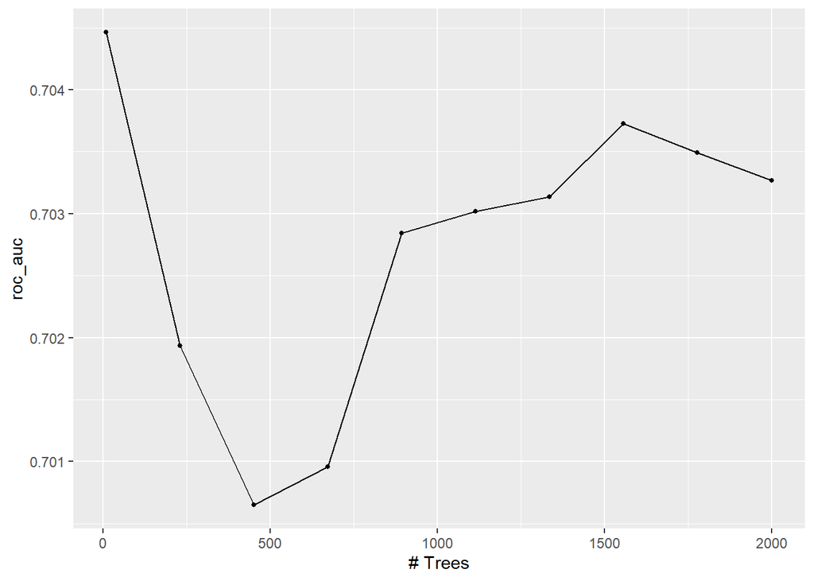

```r
# Loading the fit
boosted_tuned <- read_rds(file = "boosted.rds")

# Printing autoplot of results
autoplot(boosted_tuned)
```

It appears that the model has the highest `roc_auc` when `trees` is at the lowest value (10 in this case). The `roc_auc` drops until it starts increasing again around 500 trees up until around 1500 trees when it starts decreasing steadily again. However, it is also important to note that the range for the `roc-auc` is between ~.7 and ~.705 here. So, although the lowest number of trees is depicted in the plots as performing the best, the `roc_auc` does not really differ much between the different number of trees.

```r
# Finding roc_auc of best performing boosted tree model on folds
boosted_best_roc_auc <- boosted_tuned %>%
  collect_metrics() %>%
  arrange(desc(mean)) %>%
  head(1)

boosted_best_roc_auc
```

```
## # A tibble: 1 × 7
##   trees .metric .estimator  mean     n std_err .config
##   <int> <chr>   <chr>      <dbl> <int>   <dbl> <chr>
## 1    10 roc_auc hand_till  0.704     5  0.0146 Preprocessor1_Model01
```

The `roc_auc` of the best-performing boosted tree model on the folds is 0.7044634.

### Exercise 10

```r
# Printing table of ROC AUC values
roc_auc_tibble <- tibble(Models = c("Pruned Tree", "Random Forest", "Boosted Tree"), ROC_AUC_Value = c(decision_tree_best_roc_auc$mean, rf_best_roc_auc$mean, boosted_best_roc_auc$mean))
roc_auc_tibble
```

```
## # A tibble: 3 × 2
##   Models        ROC_AUC_Value
##   <chr>                 <dbl>
## 1 Pruned Tree           0.628
## 2 Random Forest         0.740
## 3 Boosted Tree          0.704
```

The random forest performed the best on the folds.

```r
# Fitting best model to testing set
best_rf_final <- select_best(rf_tuned)
rf_final_workflow_testing <- finalize_workflow(rf_workflow, best_rf_final)
rf_final_fit_testing <- fit(rf_final_workflow_testing, data = pokemon_test)
```

```r
final_tibble <- augment(rf_final_fit_testing, new_data = pokemon_test)

# Printing the AUC value
final_tibble %>%
  roc_auc(truth = type_1, estimate = .pred_Bug:.pred_Water)
```

```
## # A tibble: 1 × 3
##   .metric .estimator .estimate
##   <chr>   <chr>          <dbl>
## 1 roc_auc hand_till       1.00
```

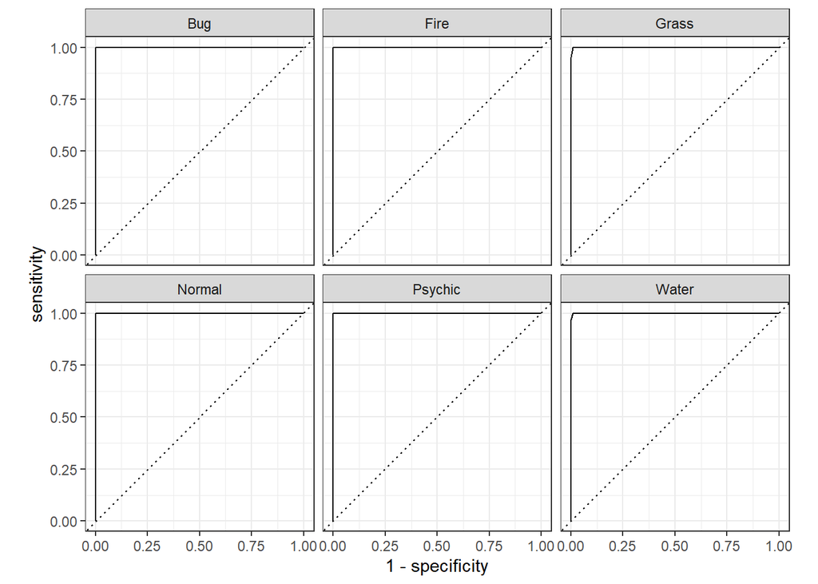

```r
# Printing the ROC curves
all_roc_curves <- final_tibble %>%
  roc_curve(truth = type_1, estimate = .pred_Bug:.pred_Water) %>%
  autoplot()
all_roc_curves
```

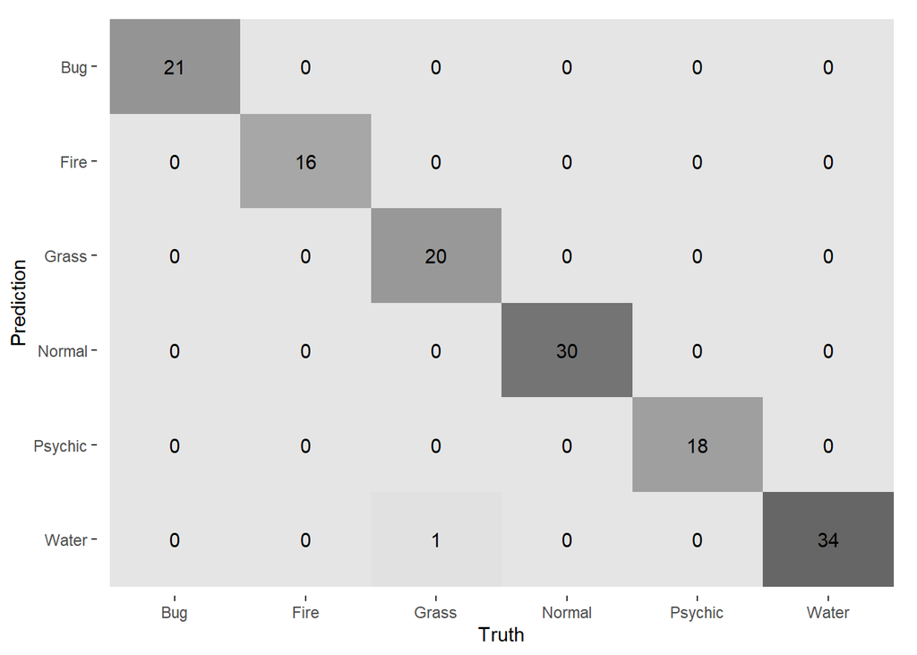

```r
# Creating and visualizing confusion matrix
confusion_matrix <- final_tibble %>%
  conf_mat(type_1, .pred_class) %>%
  autoplot(type = "heatmap")
confusion_matrix
```

The model did almost perfect in predicting every single class. However, it made only one mistake in classifying a Grass type Pokemon as Water. From the last homework, Grass type Pokemon were the most inaccurately classified Pokemon as Water so it makes sense that the model might make a small error since Grass and Water type Pokemon might be quite similar. However, I would not say that the model was the “worst” at predicting Grass type Pokemon because it only made one inaccurate classification. So the model does an almost perfect job accurately predicting every class.